# Predicting Activity Quality from Activity Monitors via Machine Learning Algorithms

Tudor Bodea

June 2015

Word count (excluding the Appendix): 1,267; Figure count: 2

**Abstract:** In this work, I report on whether or not machine learning techniques could be used to successfully identify how well certain physical activities are performed by wearers of quantified self movement devices (e.g., `Jawbone Up`, `Nike FuelBand` and `Fitbit`). Building on a data set publicly available online at `http://groupware.les.inf.puc-rio.br/har`, my analysis indicates that certain classes of machine learning techniques are well suited for the automatic and robust detection of physical activity execution mistakes. If this proves correct in other contexts, providing immediate (real-time) feedback to the user on the quality of her execution may become a (monetized) reality in the not so distant future.

#### I. Introduction

In the recent years, quantifying without supervision, that is, without a personal trainer, the quality of the execution of a physical task has started to receive increased attention. As this research area matures, it is to be expected that members of several social life groups (among others) will take full advantage of the corresponding developments and consume this information as a means to improve their health, tone and life-style. In this context, the work reported here contributes to the unsupervised identification of the quality of the execution of certain physical activities performed by wearers of quantified self movement devices. In the original study from which the data was borrowed, 6 participants equipped with on-body sensors were asked to perform repetitions of the Unilateral Dumbbell Biceps Curl in five different fashions: exactly according to the specification (Class A), or, involving the most common types of execution mistakes (Classes B through E). Using this data set, I report next on the class prediction accuracy of several machine learning techniques, algorithms that may eventually power the unsupervised guidance offered to users of self movement devices.

#### II. Data Loading, Cleaning & Transformation

The activity quality data is available in a comma separated value (csv) format from [Groupware@LES](http://groupware.les.inf.puc-rio.br/har), a group that promotes research and development of groupware technologies. Our working data set (i.e., `pml-training.csv`) consists of 19,622 records on 158 possible activity monitor predictors (or, explanatory variables). Each of these records comes with its own true activity quality class: A (according to the specifications), or, B through E (classes B through E describe various types of execution mistakes). Including the activity quality class, the working data set reflects data on 159 variables.

As a preamble to the actual analysis, I loaded the data in `R` using the `read.table` command. Since many entries in the data set were either missing strings (i.e., `""`), error codes (i.e., `"#DIV/0!"`), or, truly missing values (i.e., `NA`), I flagged all these entries as missing value entries and loaded them into `R` (via `read.table`) accordingly. Next, I summarized the content of all variables based on the number & proportion of missing values and learned that they grouped into two distinct classes: one with no missing value variables (59 variables) and another one with more than 95% missing value variables (100 variables). To summarize the variables based on the missing values, I used snippets of the code that Stephen Turner posted on his [personal blog](http://www.gettinggeneticsdone.com/2011/02/summarize-missing-data-for-all.html). To avoid subsequent sample size and computational issues, I removed the entire class of more than 95% missing value variables from the working data set. In addition, to avoid possible miss-learnings while training the machine learning algorithms, I removed from the working data set the user identifier (1 variable) and all time and time window variables (5 variables). After cleaning the data, the working data set consisted of 19,622 records on 53 variables (which included the activity quality class).

To set up a proper train and test environment for the machine learning techniques, I randomly split the working data set into training (60%) and testing (40%) data partitions using `createDataPartition` command from the contributed `R` package `caret`. I settled on the 60% percentage of data that went into the training partition for practical yet sound methodological reasons. First, I wanted the training and the testing operations to be well represented and served. Hence, a training percentage between 60% and 80% made sense. In addition, given that the higher training percentages came on my machine (see Section 1 of the Appendix) with either high run times (e.g., the `random forest` algorithm concluded in 6:34 hours when the training percentage was 75%) or RAM memory exceptions (e.g., the `naive Bayes` algorithm ran out-of-memory when the training percentage was 75%), I decided to use a training percentage of 60%. Therefore, all the results discussed in the following paragraphs reflect this ever existing trade-off between methodological needs and system requirements.

For reproducibility, I provide in Sections 1 and 2 of the Appendix the information about the current `R` session (via `sessionInfo`) and the relevant data loading, cleaning & transformation code chunks, respectively.

#### III. Data Analysis and Results

To quantify how well I recover the observed quality of the execution of the physical tasks undertaken by the wearers of self movement devices, I used several machine learning techniques including decision trees (`rpart`), random forest (`rf`) and model-based classification algorithms (linear discriminant analysis `lda` and naive Bayes `nb`). All these algorithms were trained on the training data partition and subsequently tested on the testing data set.

To train the models, I used the `train` command from the `R` contributed package `caret`. `train` is a complex wrapper that calls functions available in other `R` contributed packages. At a very high level, `train` sets up a universe (or, grid) of tuning parameters, fits the corresponding models and recommends the best one using re-sampling based performance measures. In my work, to make sure that the out-of-sample errors are contained and represented, `train` traverses the universe of tuning parameters, re-samples through 10-fold cross validation with 5 repetitions the training partition, sets up the corresponding sub-training and sub-testing partitions and determines the optimal parameter set based on the prediction performance on the sub-testing partitions. For completion, I provide insights into each of the best models in the corresponding sections of the Appendix.

**Table 1:** Accuracy Summary Statistics (Test Data Set)

[output not shown]

#### IV. Concluding Remarks

The encouraging results reported in Table 1 for random forest suggest that the machine learning techniques may prove, slowly but surely, to be capable of quantifying how well certain physical tasks are executed by wearers of self movement devices. Building on this and other similar findings, the field of human activity recognition is poised for success - as more and more applications, algorithms and devices are explored and developed, the reliance on machine learning techniques for immediate and reliable user feedback ought to become “as natural as the pattern that was made by the dust on a butterfly’s wings” (Ernst Hemingway).

### APPENDIX

[session information not shown]

#### 2. Data Loading, Cleaning & Transformation

In the `R` code chunk below, the `propmiss` function was written by Stephen Turner and is available as is on his [blog](http://www.gettinggeneticsdone.com/2011/02/summarize-missing-data-for-all.html) on genetics & bioinformatics.

```r
##### LOAD AND CLEAN UP THE DATA
# FUNCTION TO HELP FILTER OUT NA COLUMNS
propmiss <- function(dataframe) {
    m <- sapply(dataframe, function(x) {
        data.frame(
            nmiss=sum(is.na(x)),
            n=length(x),
            propmiss=sum(is.na(x))/length(x)
        )
    })
    d <- data.frame(t(m))
    d <- sapply(d, unlist)
    d <- as.data.frame(d)
    d$variable <- row.names(d)
    row.names(d) <- NULL
    d <- cbind(d[ncol(d)],d[-ncol(d)])
    return(d[order(d$propmiss), ])
}
# LOAD COURSERA TRAINING DATA
data <- read.table(file="pml-training.csv", sep=",", header=TRUE, row.names=1,
    na.strings=c("#DIV/0!", "", NA))
# SELECT AND REMOVE VARIABLES WITH MORE THAN 95% MISSING VALUES
tmp <- propmiss(data)
mv <- tmp[tmp[,4] >= 0.95,1]
data <- data[,!(names(data) %in% mv)]
# REMOVE USER NAME AND TIME RELATED VARIABLES
data <- data[,-(1:6)]
##### CREATE A TRAINING AND A TESTING DATA SET
set.seed(14398233)
inTrain <- createDataPartition(y=data$classe, p=0.6, list=FALSE)
training <- data[inTrain,]
testing <- data[-inTrain,]
##### LOAD COURSERA TESTING DATA
test <- read.table(file="pml-testing.csv", sep=",", header=TRUE, row.names=1,
    na.strings=c("#DIV/0!", "", NA))
test <- test[,names(test) %in% names(data)]
```

#### 3. Decision Trees: `train` with `rpart`

**`rpart` Model**

```r
modfit1 <- train(classe~., method="rpart", data=training, trControl =
                     trainControl(trim=TRUE, method = "repeatedcv", number = 10, repeats = 5))
print(modfit1$finalModel)
```

```
## n= 11776
##
## node), split, n, loss, yval, (yprob)
##       * denotes terminal node
##
##  1) root 11776 8428 A (0.28 0.19 0.17 0.16 0.18)
##    2) roll_belt< 130.5 10791 7451 A (0.31 0.21 0.19 0.18 0.11)
##      4) pitch_forearm< -34.35 942    3 A (1 0.0032 0 0 0) *
##      5) pitch_forearm>=-34.35 9849 7448 A (0.24 0.23 0.21 0.2 0.12)
##       10) magnet_dumbbell_y< 432.5 8253 5916 A (0.28 0.18 0.24 0.19 0.11)
##         20) roll_forearm< 126.5 5161 3055 A (0.41 0.18 0.19 0.16 0.055) *
##         21) roll_forearm>=126.5 3092 2096 C (0.075 0.17 0.32 0.24 0.19) *
##       11) magnet_dumbbell_y>=432.5 1596  804 B (0.04 0.5 0.046 0.22 0.19) *
##    3) roll_belt>=130.5 985    8 E (0.0081 0 0 0 0.99) *
```

**`rpart` Model Plot**

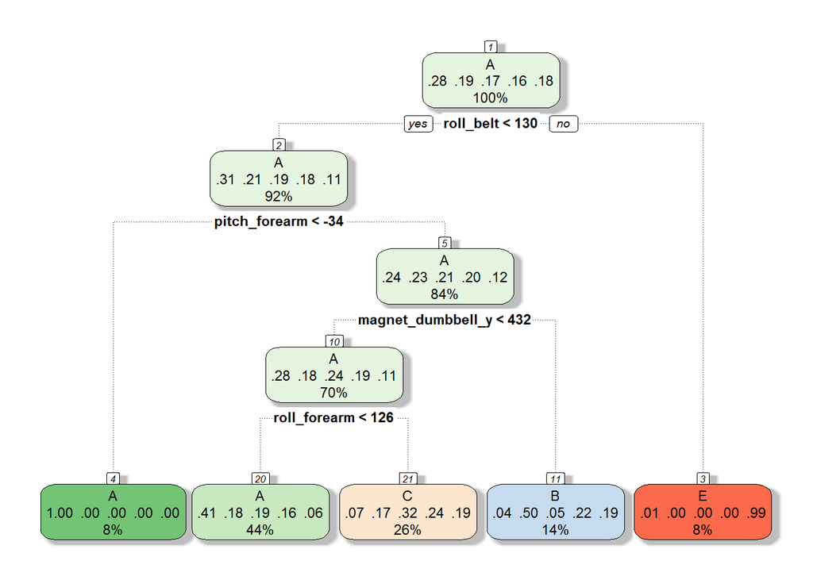

**Figure 1:** `rpart` Model Plot

**`rpart` Predict Performance on the Testing Data Set**

```
## Confusion Matrix and Statistics
##
##           Reference
## Prediction    A    B    C    D    E
##          A 2023  650  625  605  231
##          B   43  528   42  240  194
##          C  160  340  701  441  363
##          D    0    0    0    0    0
##          E    6    0    0    0  654
##
## Overall Statistics
##
##                Accuracy : 0.4978
##                  95% CI : (0.4867, 0.509)
##     No Information Rate : 0.2845
##     P-Value [Acc > NIR] : < 2.2e-16
##
##                   Kappa : 0.343
##  Mcnemar's Test P-Value : NA
##
## Statistics by Class:
##
##                      Class: A Class: B Class: C Class: D Class: E
## Sensitivity            0.9064   0.3478  0.51243   0.0000  0.45354
## Specificity            0.6240   0.9180  0.79870   1.0000  0.99906
## Pos Pred Value         0.4894   0.5043  0.34963      NaN  0.99091
## Neg Pred Value         0.9437   0.8544  0.88581   0.8361  0.89034
## Prevalence             0.2845   0.1935  0.17436   0.1639  0.18379
## Detection Rate         0.2578   0.0673  0.08934   0.0000  0.08335
## Detection Prevalence   0.5269   0.1334  0.25554   0.0000  0.08412
## Balanced Accuracy      0.7652   0.6329  0.65557   0.5000  0.72630
```

#### 4. Random Forest: `train` with `rf`

**`rf` Model**

```r
modfit2 <- train(classe~., method="rf", data=training, importance=TRUE,
                 trControl = trainControl(method = "repeatedcv", number = 10, repeats = 5))
modfit2
```

```
## Random Forest
##
## 11776 samples
##    52 predictor
##     5 classes: 'A', 'B', 'C', 'D', 'E'
##
## No pre-processing
## Resampling: Cross-Validated (10 fold, repeated 5 times)
##
## Summary of sample sizes: 10599, 10599, 10597, 10598, 10598, 10599, ...
##
## Resampling results across tuning parameters:
##
##   mtry  Accuracy   Kappa      Accuracy SD  Kappa SD
##    2    0.9894705  0.9866794  0.002594503  0.003282291
##   27    0.9898268  0.9871304  0.002778888  0.003516059
##   52    0.9860735  0.9823823  0.004295598  0.005434232
##
## Accuracy was used to select the optimal model using  the largest value.
## The final value used for the model was mtry = 27.
```

**`rf` Predict Performance on the Testing Data Set**

[output not shown]

**`rf` Variable Importance Plot**

```r
vi <- varImp(modfit2)
vi
```

```
## rf variable importance
##
##   variables are sorted by maximum importance across the classes
##   only 20 most important variables shown (out of 52)
##
##                          A      B     C     D     E
## pitch_belt           29.19 100.00 65.20 49.08 38.56
## roll_belt            88.57  99.08 89.41 82.21 94.65
## pitch_forearm        64.41  81.77 92.40 56.59 62.66
## magnet_dumbbell_y    72.25  69.40 91.55 65.49 59.16
## magnet_dumbbell_z    77.43  55.35 65.97 46.58 50.50
## yaw_belt             60.56  63.49 63.36 70.62 48.97
## accel_forearm_x      22.14  44.57 42.43 58.24 43.30
## roll_forearm         56.10  43.75 50.57 36.33 38.08
## yaw_arm              42.25  28.06 26.35 33.42 17.27
## gyros_dumbbell_y     39.69  27.87 40.75 26.85 22.54
## accel_dumbbell_y     33.51  31.34 39.75 32.31 28.68
## accel_dumbbell_z     20.37  29.06 21.12 27.02 34.96
## roll_dumbbell        18.40  33.27 18.69 21.72 27.49
## gyros_belt_z         17.45  29.96 31.67 23.68 33.09
## magnet_belt_x        14.32  31.20 26.80 14.50 22.87
## gyros_forearm_y      13.67  30.79 25.62 18.74 12.80
## magnet_forearm_z     29.39  30.34 27.45 26.73 29.79
## magnet_belt_y        14.99  30.12 27.48 19.02 24.75
## magnet_belt_z        18.79  29.83 23.96 28.43 27.40
## total_accel_dumbbell 13.63  29.00 17.97 25.95 27.71
```

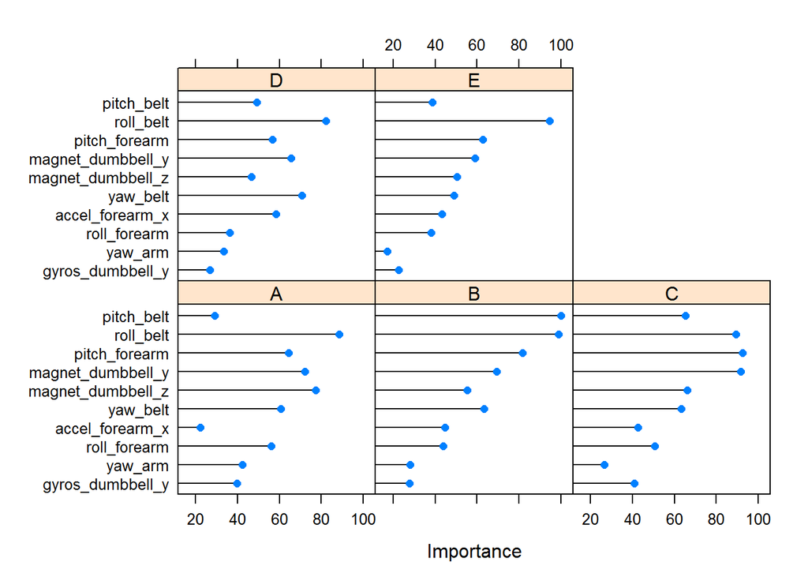

```r
# PLOT TOP 10 IMPORTANT VARIABLES
plot(vi, top = 10)
```

**Figure 2:** `rf` Variable Importance Plot

#### 5. Model Based Predictions - Linear Discriminant Analysis: `train` with `lda`

**`lda` Model**

```r
modfit3 <- train(classe~., method="lda", data=training,
                 trControl = trainControl(method = "repeatedcv", number = 10, repeats = 5))
modfit3
```

```
## Linear Discriminant Analysis
##
## 11776 samples
##    52 predictor
##     5 classes: 'A', 'B', 'C', 'D', 'E'
##
## No pre-processing
## Resampling: Cross-Validated (10 fold, repeated 5 times)
##
## Summary of sample sizes: 10600, 10598, 10598, 10598, 10599, 10599, ...
##
## Resampling results
##
##   Accuracy   Kappa      Accuracy SD  Kappa SD
##   0.6998485  0.6202329  0.01423386   0.01801717
##
##
```

**`lda` Predict Performance on the Testing Data Set**

[output not shown]

#### 6. Model Based Predictions - Naive Bayes: `train` with `nb`

**`nb` Model**

```r
modfit4 <- suppressWarnings(train(classe~., method="nb", data=training, verbose=FALSE,
                 trControl = trainControl(method = "repeatedcv", number = 10, repeats = 5)))
modfit4
```

```
## Naive Bayes
##
## 11776 samples
##    52 predictor
##     5 classes: 'A', 'B', 'C', 'D', 'E'
##
## No pre-processing
## Resampling: Cross-Validated (10 fold, repeated 5 times)
##
## Summary of sample sizes: 10600, 10597, 10597, 10598, 10600, 10598, ...
##
## Resampling results across tuning parameters:
##
##   usekernel  Accuracy   Kappa      Accuracy SD  Kappa SD
##   FALSE      0.4831871  0.3634741  0.02431070   0.02591911
##    TRUE      0.7352264  0.6617661  0.01242355   0.01588688
##
## Tuning parameter 'fL' was held constant at a value of 0
## Accuracy was used to select the optimal model using  the largest value.
## The final values used for the model were fL = 0 and usekernel = TRUE.
```

**`nb` Predict Performance on the Testing Data Set**

The predict performance summary statistics are not shown for `naive Bayes` because the `predict` function below returns a warning message of the type `Numerical 0 probability for all classes with ## observation X` for every observation X in the testing data set. These warning messages consume a lot of white space which makes the appearance of this submission not appealing. Just as an FYI, the issue of the `Numerical 0 probability` is documented [here](http://r.789695.n4.nabble.com/klaR-package-NaiveBayes-warning-message-numerical-0-probability-td3025567.html).

```r
pred4 <- predict(modfit4, testing)
cm4 <- confusionMatrix(pred4, testing$classe)
cm4
```